# Capstone Milestone Report

Sepand Haghighi

Monday, July 20, 2015

In This Project We Want To Make A Algorithm To Predict Next Words And Sentences By Natural Language Processing Technics Such As Statistical Tehcnic n-grams , And This This Report We Load And Extract Some Important Feature Of Data , In All Of The Part we Include R-Lang Code And Comment For Better Documentation. # 1.Library Import And Loading Datasets :  
In This Part We Include Library And Then Load English Data Sets , Because Its Big , We Read Lines Of It By ReadLines And Make Connection By File() Command

```r
library(stringr) #Stringr Package For Working With Str_length And Word Count
library(ggplot2) # ggplot2 Package For Plott With This Graphic System
library(stylo) # Stylo Package For Work With n-grams and convert txt to words
library(gridExtra) # GridExtra Package For Plotting Multiple Plot In ggplot2 system
```

```r
    # Useful Library For Readinf And Counting String In R
  con<-file('final/en_US/en_US.blogs.txt'); # Open A Connection For Reading File  (Blog File)
  blog_file<-readLines(con);  # Read Blog Text File By ReadLines Function
  close(con)           # Close the Connection Of File
  con<-file('final/en_US/en_US.news.txt') # Open A Connection FOr Reading File (News  File)
  news_file<-readLines(con); # Read News Text File By ReadLines Function
  close(con) # Close the Connection Of File
  con<-file('final/en_US/en_US.twitter.txt') # Open A Connection For Reading File (Twitter File)
  twitter_file<-readLines(con) # Read Twitter Text File By ReadLines Function
  close(con) # Close the Connection Of File
```

# 2. Summary Of DataSets :

In This Part We Extract Basic Information Such As Each File Length And Number Of Words For Next Steps Of This Project .

```r
  blog_length<-length(blog_file) # Get Length Of blog_file
  news_length<-length(news_file) # Get Length Of news_file
  twitter_length<-length(twitter_file) #Get Length Of twitter_file
  blog_wNumber<-sum(str_count(blog_file,"\\S+")) #Count words Number In blog_file
  news_wNumber<-sum(str_count(news_file,"\\S+")) #Count words Number In news_file
  twitter_wnumber<-sum(str_count(twitter_file,"\\S+")) #Count words Number In twitter_file
```

Summary Of Three Files :

Blog Text File Length = 899288 Number Of Words =37334441  
News Text File Length = 77259 Number Of Words =2643972  
Twitter Text File Length = 2360148 Number Of Words =30373792

# 3. Extract Some Feature :

## 1.Vowel Letter :

For This Step we Find aAeEoOiIuU In Each File

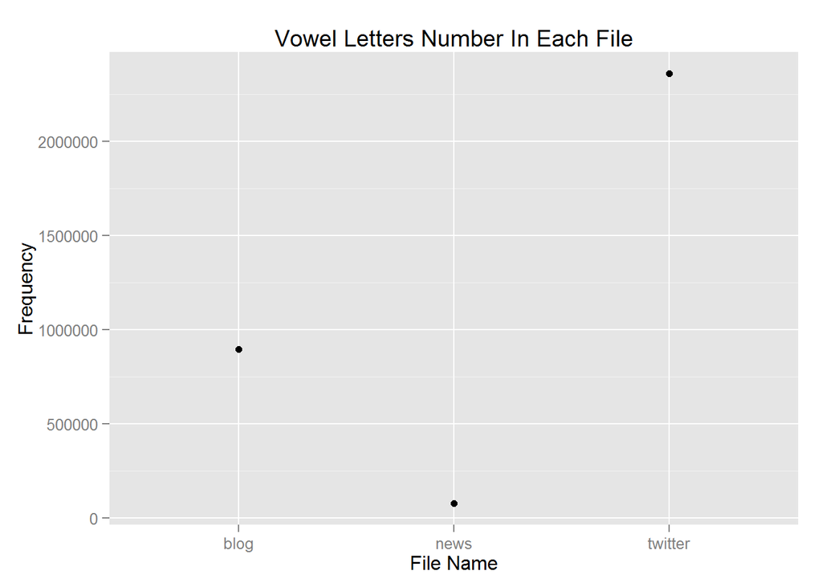

```r
vowel_letter_blog<-length(grep('[aAeEoOiIuU]',blog_file)) #Find Number Of Vowel Letters In blog_file by grep function
vowel_letter_news<-length( grep('[aAeEoOiIuU]',news_file)) #Find Number Of Vowel Letters In news_file by grep function
vowel_letter_twitter<-length(grep('[aAeEoOiIuU]',twitter_file))# Find Number Of Vowel Letters In twitter_file by grep function

x<-c('blog','news','twitter') #Create Character Vector For X Axis In Plotting
y<-c(vowel_letter_blog,vowel_letter_news,vowel_letter_twitter) # Create Character Vector For Y Axis

qplot(x,y,main="Vowel Letters Number In Each File",xlab = "File Name",ylab="Frequency") # Plot in ggplot2 System By qplot function
```

## 2.Unique Words :

In This Part We Show Number Of Unique Word In Each Text File

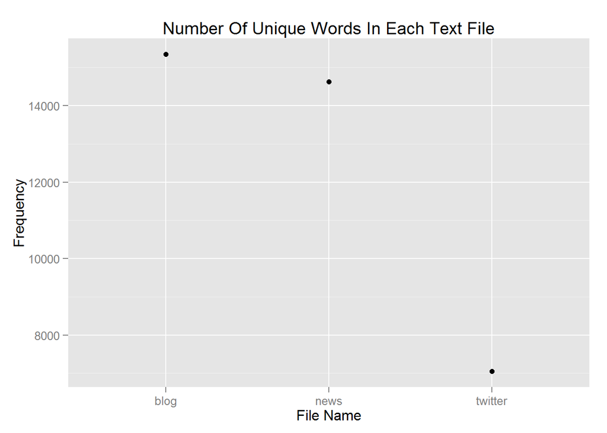

```r
sampled_blog<-sample(blog_file,replace=FALSE,size = 3000) # Get 3000 Sample Of blog_file without replacement
blog_words<-txt.to.words(sampled_blog) # Convert Text To Words By txt.to.words function in stylo library
news_words<-txt.to.words(sample(news_file,replace =FALSE,3000))
twitter_words<-txt.to.words(sample(twitter_file,replace=FALSE,3000))
unique_word<-c(length(unique(blog_words)),length(unique(news_words)),length(unique(twitter_words))) # Create Vector Of Length of Unique words In Each Text File
qplot(x,unique_word,main="Number Of Unique Words In Each Text File",xlab="File Name",ylab="Frequency") # Plot Number Of Unique Words In Each File By qplot Function
```

We Can See That Number Of Unique Word In Twitter File is Much Lower Than Two Others.

## 3.Make n-grams :

In This Part We make 2.3-grams By make.ngrams in each File Seperatly and plot Number Of This n-grams to compare.

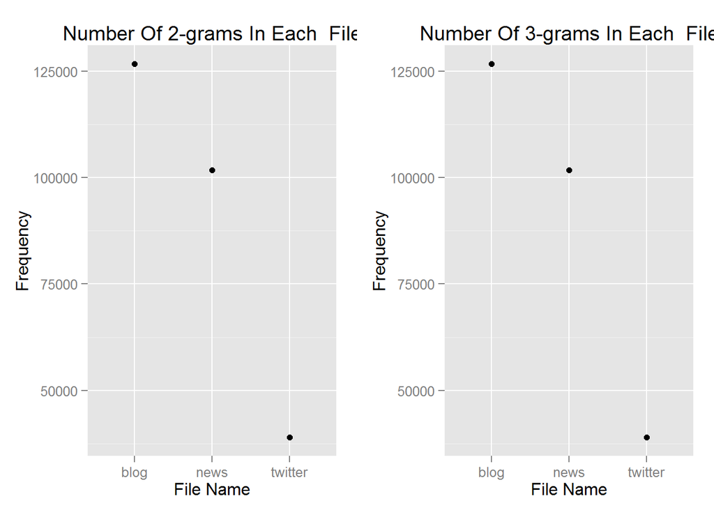

```r
gram_2_blog<-make.ngrams(blog_words,2)
gram_2_news<-make.ngrams(news_words,2)
gram_2_twitter<-make.ngrams(twitter_words,2)
gram_3_blog<-make.ngrams(blog_words,3)
gram_3_news<-make.ngrams(news_words,3)
gram_3_twitter<-make.ngrams(twitter_words,3)
grams_output<-c(length(gram_2_blog),length(gram_2_news),length(gram_2_twitter))
grams_3_output<-c(length(gram_3_blog),length(gram_3_news),length(gram_3_twitter))
p1<-qplot(c('blog','news','twitter'),grams_output,main="Number Of 2-grams In Each  File",xlab="File Name",ylab="Frequency")
p2<-qplot(c('blog','news','twitter'),grams_3_output,main="Number Of 3-grams In Each  File",xlab="File Name",ylab="Frequency")
grid.arrange(p1,p2,ncol=2)
```